# Practice Workbook: Machine Learning with R

2023-11-27

# Solution Workbook: Machine Learning with R Course

**Machine learning with R** refers to the use of the R programming language and its associated libraries, packages, and frameworks to implement, explore, and deploy machine learning models and algorithms.

1. **Supervised learning** is a machine learning technique where algorithms learn from labeled training data, with input-output pairs provided, to predict or infer a mapping function from the input to the output.
   - Examples: Predicting whether an email is spam or not (classification). Forecasting house prices based on features like size, location, and number of rooms (regression).
2. **Unsupervised learning** involves training algorithms on unlabeled data, where the algorithm learns patterns, structures, or relationships within the data without explicit input-output pairs.
   - Examples: Grouping customers based on purchasing behavior for targeted marketing (clustering). Reducing the dimensions of high-dimensional data for easier visualization and analysis (principal component analysis).

## Regression Algorithms

### Pre-requisites

```r
# Install the caret package
# We'll use the caret packaget to build and evaluate machine learning models
install.packages("caret", quiet = TRUE)
```

[output not shown]

```r
# Load the caret packaget
library(caret)
# Read CSV file from URL
data <- read.csv("https://bit.ly/3RjxkTs")

# Preview 6 records
head(data)
```

```
##   ID  Name Experience     Skills Education           Job.Role Salary
## 1  1  John          5       Java    Master Software Developer  70000
## 2  2  Jane          3     Python  Bachelor       Data Analyst  60000
## 3  3   Bob          7        C++       PhD    Systems Analyst  80000
## 4  4 Sarah          2 JavaScript  Bachelor      Web Developer  55000
## 5  5  Anna          6     Python    Master     Data Scientist  85000
## 6  6  Mark          4       Java       PhD Software Developer  75000
```

```r
# Handle missing values or NAs
data <- na.omit(data)

# Convert columns to appropriate data types
data$Experience <- as.numeric(data$Experience)
data$Salary <- as.numeric(data$Salary)
data$Skills <- as.factor(data$Skills)
data$Education <- as.factor(data$Education)
data$Job.Role <- as.factor(data$Job.Role)

# Remove 'Name' column
data <- data[, -which(names(data) == "Name")]

# Set seed for reproducibility
set.seed(123)

# Split data into training and testing sets
splitIndex <- createDataPartition(data$Salary, p = .70, list = FALSE)
train <- data[splitIndex,]
test <- data[-splitIndex,]
```

### Concept 1. Linear Regression

This algorithm establishes a linear relationship between predictors and a continuous target variable, aiming to minimize the difference between predicted and actual values. It’s suitable when exploring relationships between variables or predicting outcomes when a linear relationship is assumed or observed. For instance, in finance, linear regression can be used to predict stock prices based on historical data.

To develop a linear regression model, we use the `lm` function in R.

```r
# Linear regression
lm_model <- lm(Salary ~ ., data = train)
```

- We use `Salary ~ .` to specify that the model predicts the “Salary” variable using all other variables in the `train` dataset.
- We set `data = train` to specify that the data used to build the linear regression model is sourced from the `train` dataset.

```r
# Make predictions on testing set
predictions <- predict(lm_model, newdata = test)
```

- We set `newdata = test` to indicate that we linear regression model (`lm_model`) to generate predictions based on the data in the `test` dataset.

```r
# Calculate RMSE
rmse <- sqrt(mean((test$Salary - predictions)^2))
print(paste("Root Mean Squared Error (RMSE):", rmse))
```

```
## [1] "Root Mean Squared Error (RMSE): 7818.91079016544"
```

- We calculate the Root Mean Squared Error (RMSE) by measuring the square root of the average of the squared differences between the actual “Salary” values in the `test` dataset and the predicted values (`predictions`) obtained from the model.

### Challenge 1

```r
# Question: Create a linear regression model in R to predict the 'Salary' based on 'Age', 'Gender', 'Experience', 'Education', and 'Job Role' from the dataset located at https://bit.ly/3RDMZgR

# Your code goes here
```

```r
# Read CSV file from URL
data <- read.csv("https://bit.ly/3RDMZgR")

# Preview 6 records
head(data)
```

```
##   ID  Name Age Gender Experience Education           Job.Role Salary
## 1  1  John  25   Male          2  Bachelor Software Developer  50000
## 2  2 Susan  36 Female         10    Master    Project Manager  80000
## 3  3   Bob  47   Male         20  Bachelor     System Analyst  78000
## 4  4 Sarah  28 Female          4       PhD     Data Scientist  90000
## 5  5  Anna  31 Female          6  Bachelor Software Developer  60000
## 6  6  Mark  40   Male         15    Master         IT Manager  95000
```

```r
# Convert columns to appropriate data types
data$Gender <- as.factor(data$Gender)
data$Education <- as.factor(data$Education)
data$Job.Role <- as.factor(data$Job.Role)

# Remove 'Name' column
data <- data[, -which(names(data) == "Name")]

# Set seed for reproducibility
set.seed(123)

# Split data into training and testing sets
splitIndex <- createDataPartition(data$Salary, p = .80, list = FALSE)
train <- data[splitIndex,]
test <- data[-splitIndex,]
```

```r
# Linear regression
lm_model <- lm(Salary ~ ., data = train)

# Make predictions on testing set
predictions <- predict(lm_model, newdata = test)

# Calculate RMSE
rmse <- sqrt(mean((test$Salary - predictions)^2))
print(paste("Root Mean Squared Error (RMSE):", rmse))
```

```
## [1] "Root Mean Squared Error (RMSE): 5419.42976321012"
```

### Concept 2. Decision Trees for Regression

This algorithm segments the predictor space into smaller regions, predicting numerical outcomes based on these divisions. We use this algorithm when the relationships between predictors and the target variable are nonlinear or involve interactions between variables. For instance, in retail, decision trees can predict sales based on various factors like promotions, location, and seasonality.

We use the `rpart` package in R to implement this algorithm.

```r
# Load necessary libraries if not already loaded
library(rpart)
```

```r
# Decision Trees
dt_model <- rpart(Salary ~ ., data = train)

# Make predictions on testing set
predictions <- predict(dt_model, newdata = test)

# Calculate RMSE
rmse <- sqrt(mean((test$Salary - predictions)^2))
print(paste("Root Mean Squared Error (RMSE):", rmse))
```

```
## [1] "Root Mean Squared Error (RMSE): 10675.9113105102"
```

### Challenge 2

```r
# Question: Create a decision trees regression model in R to predict the 'Salary' based on 'Age', 'Gender', 'Experience', 'Education', and 'Job Role' from the dataset located at https://bit.ly/3RDMZgR

# Your code goes here

# Decision Trees
dt_model <- rpart(Salary ~ ., data = train)

# Make predictions on testing set
predictions <- predict(dt_model, newdata = test)

# Calculate RMSE
rmse <- sqrt(mean((test$Salary - predictions)^2))
print(paste("Root Mean Squared Error (RMSE):", rmse))
```

```
## [1] "Root Mean Squared Error (RMSE): 10675.9113105102"
```

### Concept 3. Support Vector Machines (SVM) for Regression

The SVM regression algorithm finds the best-fitting hyperplane to predict continuous outcomes, aiming to maximize the margin between data points. It’s suitable for smaller datasets or when dealing with complex relationships and outliers. For example, in climate science, we can use SVM regression to forecast temperatures based on various meteorological factors.

We use the `e1071` package in R to work with this algorithm.

```r
install.packages("e1071", quiet = TRUE)
library(e1071)
# Support Vector Machines (SVM) for Regression
svm_model <- svm(Salary ~ ., data = train)

# Make predictions on testing set
predictions <- predict(svm_model, newdata = test)

# Calculate RMSE
rmse <- sqrt(mean((test$Salary - predictions)^2))
print(paste("Root Mean Squared Error (RMSE):", rmse))
```

```
## [1] "Root Mean Squared Error (RMSE): 8665.40898231943"
```

### Challenge 3

```r
# Question: Create a support vector regression model in R to predict the 'Salary' based on 'Age', 'Gender', 'Experience', 'Education', and 'Job Role' from the dataset located at https://bit.ly/3RDMZgR

# Your code goes here

# Support Vector Machines (SVM) for Regression
svm_model <- svm(Salary ~ ., data = train)

# Make predictions on testing set
predictions <- predict(svm_model, newdata = test)

# Calculate RMSE
rmse <- sqrt(mean((test$Salary - predictions)^2))
print(paste("Root Mean Squared Error (RMSE):", rmse))
```

```
## [1] "Root Mean Squared Error (RMSE): 8665.40898231943"
```

### Concept 4. Random Forest for Regression

The random forest algorithm aggregates predictions from multiple decision trees to improve predictive accuracy by reducing overfitting. It’s suitable for large datasets with numerous predictors and are robust against overfitting. For instance, in healthcare, random forest regression can predict patient treatment costs based on various health indicators and medical history.

To work with this algorithm, we use the `randomForest` package in R.

```r
install.packages("randomForest", quiet = TRUE)
# Import the random
library(randomForest)
# Random Forest for Regression
rf_model <- randomForest(Salary ~ ., data = train)

# Make predictions on testing set
predictions <- predict(rf_model, newdata = test)

# Calculate RMSE
rmse <- sqrt(mean((test$Salary - predictions)^2))
print(paste("Root Mean Squared Error (RMSE):", rmse))
```

```
## [1] "Root Mean Squared Error (RMSE): 7534.68861059355"
```

### Challenge 4

```r
# Question: Create a random forest regression model in R to predict the 'Salary' based on 'Age', 'Gender', 'Experience', 'Education', and 'Job Role' from the dataset located at https://bit.ly/3RDMZgR

# Your code goes here

# Random Forest for Regression
rf_model <- randomForest(Salary ~ ., data = train)

# Make predictions on testing set
predictions <- predict(rf_model, newdata = test)

# Calculate RMSE
rmse <- sqrt(mean((test$Salary - predictions)^2))
print(paste("Root Mean Squared Error (RMSE):", rmse))
```

```
## [1] "Root Mean Squared Error (RMSE): 7257.53802198007"
```

### Concept 5. Gradient Boosting Machines (GBM) for Regression

A GBM algorithm iteratively builds an ensemble of weak regression algorithms, sequentially minimizing errors to improve predictions. It’s useful for enhancing prediction accuracy by combining multiple weak learners. For example, in marketing, GBM regression can predict customer lifetime value based on past purchase behavior and demographic information.

We use the `gbm` package in R to work with this algorithm.

```r
install.packages("gbm", quiet = TRUE)
# Load necessary libraries if not already loaded
library(gbm)
# Gradient Boosting Machines (GBM) for Regression
gbm_model <- gbm(Salary ~ ., data = data)
```

```
## Distribution not specified, assuming gaussian ...
```

```r
# Make predictions on testing set
predictions <- predict(gbm_model, newdata = test)
```

```
## Using 100 trees...
```

```r
# Calculate RMSE
rmse <- sqrt(mean((test$Salary - predictions)^2))
print(paste("Root Mean Squared Error (RMSE):", rmse))
```

```
## [1] "Root Mean Squared Error (RMSE): 4089.00895640301"
```

### Challenge 5

```r
# Question: Create a gbm model in R to predict the 'Salary' based on 'Age', 'Gender', 'Experience', 'Education', and 'Job Role' from the dataset located at https://bit.ly/3RDMZgR

# Your code goes here

# Gradient Boosting Machines (GBM) for Regression
gbm_model <- gbm(Salary ~ ., data = data)
```

```
## Distribution not specified, assuming gaussian ...
```

```r
# Make predictions on testing set
predictions <- predict(gbm_model, newdata = test)
```

```
## Using 100 trees...
```

```r
# Calculate RMSE
rmse <- sqrt(mean((test$Salary - predictions)^2))
print(paste("Root Mean Squared Error (RMSE):", rmse))
```

```
## [1] "Root Mean Squared Error (RMSE): 4112.20889783138"
```

## Classification Algorithms

### Prerequisites

```r
# Load the dataset
# Read CSV file from URL and store it in the 'data' variable
data <- read.csv("https://bit.ly/3N8NWe6")

# Preview the dataframe
head(data)
```

```
##   ID  Name Experience Gender Salary Education Job_Satisfaction
## 1  1  John          5   Male  50000  Bachelor                1
## 2  2  Jane         10 Female  70000    Master                0
## 3  3   Bob         15   Male  78000  Bachelor                1
## 4  4 Sarah          3 Female  62000       PhD                0
## 5  5  Anna          7 Female  44000  Bachelor                1
## 6  6  Mark         12   Male  80000    Master                1
```

```r
# Convert 'Gender' and 'Education' columns to numeric factors
data$Gender <- as.numeric(factor(data$Gender))
data$Education <- as.numeric(factor(data$Education))

# Preview dataframe
head(data)
```

```
##   ID  Name Experience Gender Salary Education Job_Satisfaction
## 1  1  John          5      2  50000         1                1
## 2  2  Jane         10      1  70000         3                0
## 3  3   Bob         15      2  78000         1                1
## 4  4 Sarah          3      1  62000         4                0
## 5  5  Anna          7      1  44000         1                1
## 6  6  Mark         12      2  80000         3                1
```

```r
# Remove 'Name' column
data <- data[, -which(names(data) == "Name")]
```

```r
# Set seed for reproducibility
set.seed(123)

# Create a partition index for the data
splitIndex <- createDataPartition(data$Job_Satisfaction, p = .80, list = FALSE)

# Create 'train' and 'test' datasets based on the split index
train <- data[splitIndex,]
test <- data[-splitIndex,]
```

### Concept 6. Logistic Regression

This algorithm models the probability of binary outcomes using a logistic function, making them suitable for binary classification problems. It’s ideal for scenarios where interpreting the probability of a binary outcome is essential. For instance, in healthcare, logistic regression can predict the likelihood of a patient having a specific disease based on medical test results.

To work with this algorithm, we use the `glm` function.

```r
# Logistic Regression
model <- glm(Job_Satisfaction ~ ., family = binomial, data = train)

# Make predictions on the test data
predictions <- predict(model, newdata = test)
```

```r
# Create a confusion matrix to evaluate the performance of the model
confusionMatrix(as.factor(ifelse(predictions > 0.5, 1, 0)), as.factor(test$Job_Satisfaction))
```

```
## Confusion Matrix and Statistics
##
##           Reference
## Prediction 0 1
##          0 6 2
##          1 0 4
##
##                Accuracy : 0.8333
##                  95% CI : (0.5159, 0.9791)
##     No Information Rate : 0.5
##     P-Value [Acc > NIR] : 0.01929
##
##                   Kappa : 0.6667
##
##  Mcnemar's Test P-Value : 0.47950
##
##             Sensitivity : 1.0000
##             Specificity : 0.6667
##          Pos Pred Value : 0.7500
##          Neg Pred Value : 1.0000
##              Prevalence : 0.5000
##          Detection Rate : 0.5000
##    Detection Prevalence : 0.6667
##       Balanced Accuracy : 0.8333
##
##        'Positive' Class : 0
##
```

- We use the `confusionMatrix` function to evaluate the classification performance by comparing the predicted values (converted to factors based on a threshold of 0.5 using `ifelse(predictions > 0.5, 1, 0)`) against the actual values of the “Job_Satisfaction” variable in the `test` dataset.

### Challenge 6

```r
# Question: Create a logistic regression model using the dataset from https://bit.ly/3TfdES7 to predict the 'Job Change' based on 'Experience', 'Years in Current Role', 'Skills', 'Education Level', 'Salary', and 'Job Satisfaction'. Use the glm() function in R, specifying the binary outcome variable and the predictor variables in the formula argument, and setting the family argument to 'binomial'.

# Your code goes here

# Load the data
```

```r
# Load the data
data <- read.csv("https://bit.ly/3TfdES7")

# Handle missing values or NAs
data <- na.omit(data)

# Convert categorical variables to numeric
data$Skills <- as.numeric(factor(data$Skills))
data$`Education.Level` <- as.numeric(factor(data$`Education.Level`))

# Transform `Job Change` column with "Yes" and "No" values to 0 and 1
data$`Job.Change` <- ifelse(data$`Job.Change` == "Yes", 1, 0)

# Set seed for reproducibility
set.seed(123)

# Split the data into training and test sets
splitIndex <- createDataPartition(data$`Job.Change`, p = .80, list=FALSE)
train <- data[splitIndex,]
test <- data[-splitIndex,]

# Create the logistic regression model
model <- glm(`Job.Change` ~ ., family = binomial, data = train)

# Make predictions on the test set
predictions <- predict(model, newdata = test, type = "response")

# Create a confusion matrix to evaluate the model
confusionMatrix(as.factor(ifelse(predictions > 0.5, 1, 0)), as.factor(test$`Job.Change`))
```

```
## Confusion Matrix and Statistics
##
##           Reference
## Prediction  0  1
##          0 10  5
##          1  1  4
##
##                Accuracy : 0.7
##                  95% CI : (0.4572, 0.8811)
##     No Information Rate : 0.55
##     P-Value [Acc > NIR] : 0.1299
##
##                   Kappa : 0.3684
##
##  Mcnemar's Test P-Value : 0.2207
##
##             Sensitivity : 0.9091
##             Specificity : 0.4444
##          Pos Pred Value : 0.6667
##          Neg Pred Value : 0.8000
##              Prevalence : 0.5500
##          Detection Rate : 0.5000
##    Detection Prevalence : 0.7500
##       Balanced Accuracy : 0.6768
##
##        'Positive' Class : 0
##
```

### Concept 7. Support Vector Machines (SVM) for Classification

The SVM classification algorithm finds the optimal hyperplane for separating classes in the feature space, adjusted by kernel types and regularization. It’s effective for binary or multi-class classification with complex boundaries, like classifying images into different categories based on pixel values.

We use `e1071` package in R to work with this algorithm.

```r
# Load necessary libraries if not already loaded
library(e1071)
```

```r
names(train)
```

```
## [1] "ID"                    "Experience"            "Years.in.Current.Role"
## [4] "Skills"                "Education.Level"       "Salary"
## [7] "Job.Satisfaction"      "Job.Change"
```

```r
# Support Vector Machines (SVM) for Classification
svm_model <- svm(as.factor(Job.Satisfaction) ~ ., data = train)

# Make predictions on the test data
predictions <- predict(svm_model, newdata = test)
```

```r
# Compute the confusion matrix
confusionMatrix(predictions, as.factor(test$Job.Satisfaction))
```

```
## Confusion Matrix and Statistics
##
##           Reference
## Prediction High Low Medium
##     High      9   1      5
##     Low       1   2      1
##     Medium    1   0      0
##
## Overall Statistics
##
##                Accuracy : 0.55
##                  95% CI : (0.3153, 0.7694)
##     No Information Rate : 0.55
##     P-Value [Acc > NIR] : 0.5914
##
##                   Kappa : 0.1705
##
##  Mcnemar's Test P-Value : 0.2998
##
## Statistics by Class:
##
##                      Class: High Class: Low Class: Medium
## Sensitivity               0.8182     0.6667        0.0000
## Specificity               0.3333     0.8824        0.9286
## Pos Pred Value            0.6000     0.5000        0.0000
## Neg Pred Value            0.6000     0.9375        0.6842
## Prevalence                0.5500     0.1500        0.3000
## Detection Rate            0.4500     0.1000        0.0000
## Detection Prevalence      0.7500     0.2000        0.0500
## Balanced Accuracy         0.5758     0.7745        0.4643
```

### Challenge 7

```r
# Question: Create a support vector regression model using the dataset from https://bit.ly/3TfdES7 to predict the 'Job Change' based on 'Experience', 'Years in Current Role', 'Skills', 'Education Level', 'Salary', and 'Job Satisfaction'.

# Your code goes here

# Support Vector Machines (SVM) for Classification
svm_model <- svm(as.factor(`Job.Change`) ~ ., data = train)

# Make predictions on the test data
predictions <- predict(svm_model, newdata = test)

# Create a confusion matrix to evaluate the performance of the model
confusionMatrix(predictions, as.factor(test$`Job.Change`))
```

```
## Confusion Matrix and Statistics
##
##           Reference
## Prediction 0 1
##          0 9 2
##          1 2 7
##
##                Accuracy : 0.8
##                  95% CI : (0.5634, 0.9427)
##     No Information Rate : 0.55
##     P-Value [Acc > NIR] : 0.01886
##
##                   Kappa : 0.596
##
##  Mcnemar's Test P-Value : 1.00000
##
##             Sensitivity : 0.8182
##             Specificity : 0.7778
##          Pos Pred Value : 0.8182
##          Neg Pred Value : 0.7778
##              Prevalence : 0.5500
##          Detection Rate : 0.4500
##    Detection Prevalence : 0.5500
##       Balanced Accuracy : 0.7980
##
##        'Positive' Class : 0
##
```

### Concept 8. Random Forest for Classification

Leveraging the `randomForest` package in R, a random forest algorithm aggregates predictions from multiple decision trees to enhance classification accuracy while controlling overfitting. Random forest for classification suitable for complex datasets with numerous predictors and non-linear relationships, for instance, classifying customer segments based on various demographic and behavioral features.

```r
install.packages("randomForest", quiet = TRUE)
# Load randomForest
library(randomForest)
```

```r
# Random Forest for Classification
rf_model <- randomForest(as.factor(Job.Satisfaction) ~ ., data = train)

# Make predictions on testing set
predictions <- predict(rf_model, newdata = test)

# Compute the confusion matrix
confusionMatrix(predictions, as.factor(test$Job.Satisfaction))
```

```
## Confusion Matrix and Statistics
##
##           Reference
## Prediction High Low Medium
##     High      6   0      4
##     Low       2   2      1
##     Medium    3   1      1
##
## Overall Statistics
##
##                Accuracy : 0.45
##                  95% CI : (0.2306, 0.6847)
##     No Information Rate : 0.55
##     P-Value [Acc > NIR] : 0.8692
##
##                   Kappa : 0.102
##
##  Mcnemar's Test P-Value : 0.5433
##
## Statistics by Class:
##
##                      Class: High Class: Low Class: Medium
## Sensitivity               0.5455     0.6667        0.1667
## Specificity               0.5556     0.8235        0.7143
## Pos Pred Value            0.6000     0.4000        0.2000
## Neg Pred Value            0.5000     0.9333        0.6667
## Prevalence                0.5500     0.1500        0.3000
## Detection Rate            0.3000     0.1000        0.0500
## Detection Prevalence      0.5000     0.2500        0.2500
## Balanced Accuracy         0.5505     0.7451        0.4405
```

### Challenge 8

```r
# Question: Create a random forest model using the dataset from https://bit.ly/3TfdES7 to predict the 'Job Change' based on 'Experience', 'Years in Current Role', 'Skills', 'Education Level', 'Salary', and 'Job Satisfaction'.

# Your code goes here

# Random Forest for Classification
rf_model <- randomForest(as.factor(`Job.Change`) ~ ., data = train)

# Make predictions on testing set
predictions <- predict(rf_model, newdata = test)

# Compute the confusion matrix
confusionMatrix(predictions, as.factor(test$`Job.Change`))
```

```
## Confusion Matrix and Statistics
##
##           Reference
## Prediction  0  1
##          0 11  4
##          1  0  5
##
##                Accuracy : 0.8
##                  95% CI : (0.5634, 0.9427)
##     No Information Rate : 0.55
##     P-Value [Acc > NIR] : 0.01886
##
##                   Kappa : 0.5789
##
##  Mcnemar's Test P-Value : 0.13361
##
##             Sensitivity : 1.0000
##             Specificity : 0.5556
##          Pos Pred Value : 0.7333
##          Neg Pred Value : 1.0000
##              Prevalence : 0.5500
##          Detection Rate : 0.5500
##    Detection Prevalence : 0.7500
##       Balanced Accuracy : 0.7778
##
##        'Positive' Class : 0
##
```

## Unsupervised learning

**Unsupervised learning** is a branch of machine learning where the algorithms are trained on unlabeled data without any specific target variable or explicit feedback.

In unsupervised learning, the primary goal is to uncover underlying patterns, structures, or relationships within the data.

### Concept 9: Clustering

**Clustering** in unsupervised learning is a technique used to group similar data points together based on their inherent characteristics or proximity in the feature space. The primary goal of clustering is to identify natural groupings or clusters within a dataset without any predefined labels or target variables.

```r
# Load necessary libraries
library(tidyverse)  # For data manipulation and visualization
library(caret)      # For machine learning tools
library(mlr)        # For machine learning in R
# We read the dataset from a URL and preprocess it
data <- read_csv("https://afterwork.ai/ds/e/information_technology_1l9rp.csv")
data
```

```
## # A tibble: 20 × 6
##       ID Name      Experience Years in Current Rol…¹ Skills `Projects Completed`
##    <dbl> <chr>          <dbl>                  <dbl> <chr>                 <dbl>
##  1     1 John               5                      2 Java                     10
##  2     2 Jane               8                      3 Python                   15
##  3     3 Bob               10                      5 C++                      20
##  4     4 Sarah              3                      1 JavaS…                    5
##  5     5 Anna               7                      3 Python                   12
##  6     6 Mark               9                      4 Java                     18
##  7     7 Samantha           4                      2 C++                       8
##  8     8 Dave               6                      3 JavaS…                   11
##  9     9 Jennifer           8                      4 Python                   14
## 10    10 Michael            5                      2 Java                      9
## 11    11 Emma               7                      3 C++                      13
## 12    12 Oliver            10                      5 JavaS…                   20
## 13    13 Noah               3                      1 Python                    6
## 14    14 Liam               9                      4 C++                      17
## 15    15 Ava                4                      2 Java                      7
## 16    16 Sophia             6                      3 JavaS…                   10
## 17    17 Mia                8                      4 Python                   15
## 18    18 Charlotte          5                      2 C++                       9
## 19    19 Amelia             7                      3 Java                     12
## 20    20 Harper            10                      5 JavaS…                   19
## # ℹ abbreviated name: ¹`Years in Current Role`
```

```r
# We select specific columns for clustering and scaling the data
data <- data %>%
  as.data.frame() %>%
  select(Experience, `Years in Current Role`, `Projects Completed`) %>%
  scale()

# Preview data
head(data)
```

```
##      Experience Years in Current Role Projects Completed
## [1,] -0.7402729           -0.85063219         -0.5388342
## [2,]  0.5660911           -0.04050629          0.5388342
## [3,]  1.4370004            1.57974550          1.6165026
## [4,] -1.6111822           -1.66075809         -1.6165026
## [5,]  0.1306364           -0.04050629         -0.1077668
## [6,]  1.0015457            0.76961960          1.1854352
```

```r
# We perform K-means clustering with k = 3
kmeans_model <- kmeans(data, centers = 3)

# We assign clusters to the original dataset and convert to a data frame
data <- data %>%
  as.data.frame() %>%
  mutate(cluster = kmeans_model$cluster)

# We preview the dataframe
head(data)
```

```
##   Experience Years in Current Role Projects Completed cluster
## 1 -0.7402729           -0.85063219         -0.5388342       1
## 2  0.5660911           -0.04050629          0.5388342       2
## 3  1.4370004            1.57974550          1.6165026       3
## 4 -1.6111822           -1.66075809         -1.6165026       1
## 5  0.1306364           -0.04050629         -0.1077668       2
## 6  1.0015457            0.76961960          1.1854352       3
```

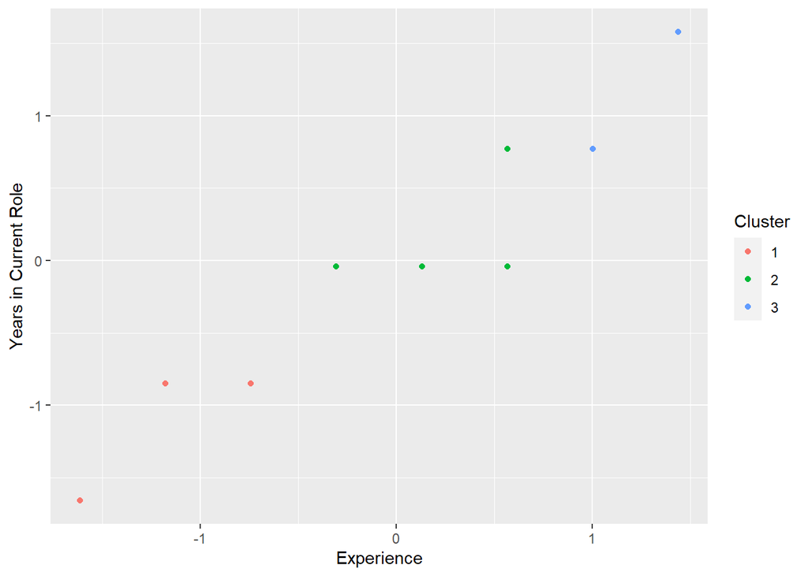

```r
# We visualize clusters using a scatter plot
ggplot(data, aes(Experience, `Years in Current Role`, color = as.factor(cluster))) +
  geom_point() +
  labs(color = "Cluster")
```

- We create a scatterplot using the “Experience” and “Years in Current Role” variables from the `data` dataset.
- The points are colored based on the clusters indicated by the `cluster` variable (converted to a factor) to visually represent different clusters in the data.
- The `labs` function sets the color legend label as “Cluster”.

**Elbow Method for Optimal K (Number of Clusters)**

```r
# We perform the Elbow Method to determine the optimal number of clusters (K)
wss <- numeric(10)  # Within-cluster sum of squares
for (i in 1:10) {
  kmeans_temp <- kmeans(data, centers = i)
  wss[i] <- kmeans_temp$tot.withinss
}
```

- We initialize an empty numeric vector `wss` to store within-cluster sum of squares values.
- We then conduct a loop from 1 to 10, performing k-means clustering on the `data` for different numbers of clusters (from 1 to 10) and store the within-cluster sum of squares in the `wss` vector for each iteration.

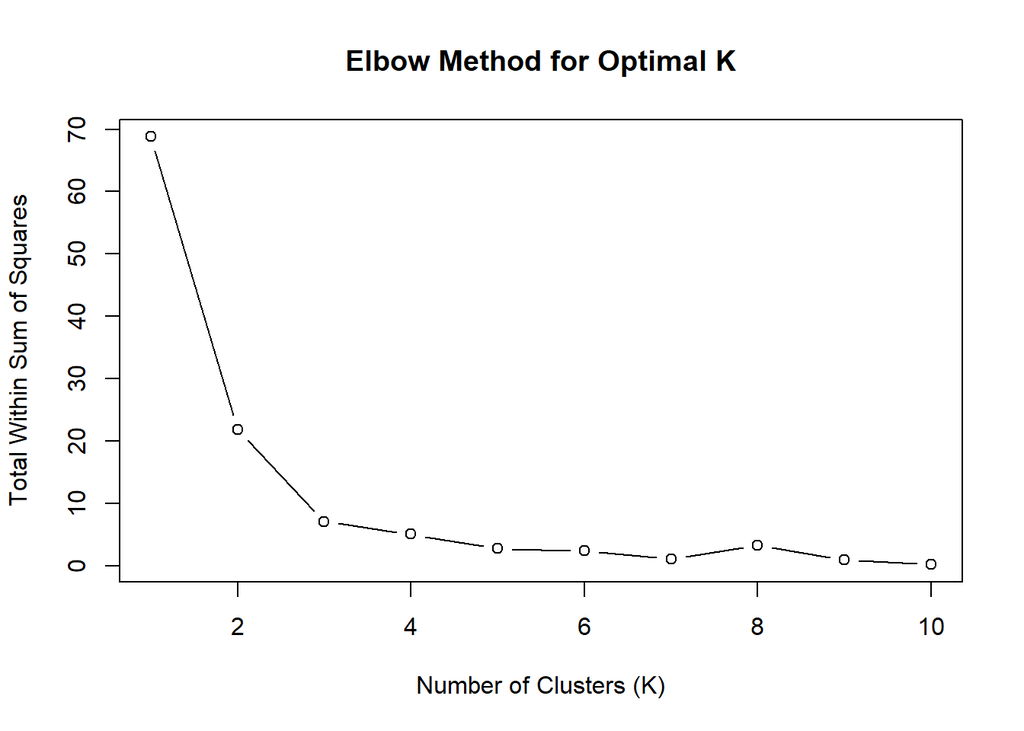

```r
# Plotting the Elbow Method graph
plot(1:10, wss, type = "b", xlab = "Number of Clusters (K)", ylab = "Total Within Sum of Squares", main = "Elbow Method for Optimal K")
```

- We generate a plot showing the within-cluster sum of squares (`wss`) against the number of clusters (from 1 to 10) using a line plot (`type = "b"`). The x-axis represents the number of clusters (K), while the y-axis displays the total within-cluster sum of squares.
- We use this plot to identify an optimal number of clusters by looking for an ‘elbow’ point where the rate of decrease in within-cluster sum of squares slows down.

### Challenge 9

```r
# Question: Use the K-Means Clustering algorithm to group the employees in the dataset located at https://afterwork.ai/ds/ch/information_technology_vw1t.csv based on their 'Experience', 'Years in Company', and 'Projects Completed'. Assume that you want to identify 3 clusters.

# Your code goes here
```

```r
# Load the required libraries
library(tidyverse)
library(caret)
library(mlr)
```

```r
# Load the data
data <- read_csv("https://afterwork.ai/ds/ch/information_technology_vw1t.csv")
```

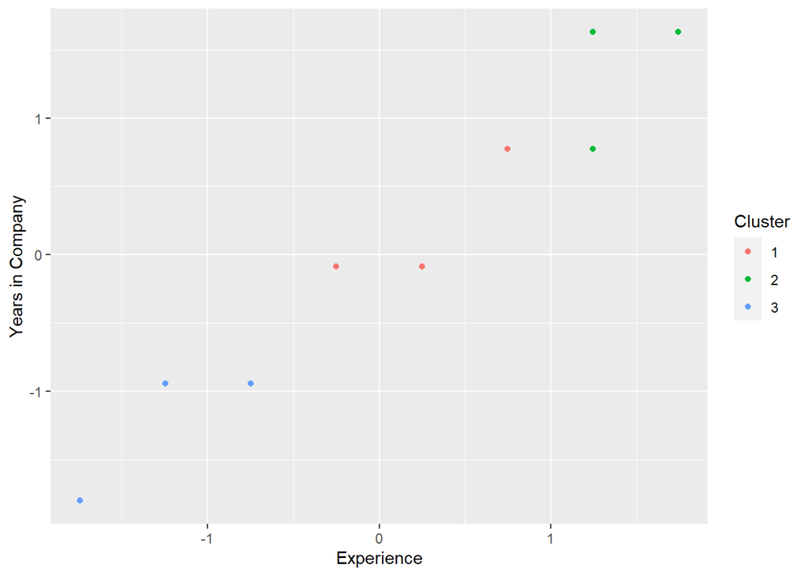

```r
# Select the relevant columns and scale the data
data <- data %>%
  select(Experience, `Years in Company`, `Projects Completed`) %>%
  scale()

# Perform K-Means Clustering
kmeans_model <- kmeans(data, centers = 3)

# Add the cluster assignments to the data
data <- data %>%
  as.data.frame() %>%
  mutate(cluster = kmeans_model$cluster)

# Plot the clusters
ggplot(data, aes(Experience, `Years in Company`, color = as.factor(cluster))) +
  geom_point() +
  labs(color = "Cluster")
```

### Concept 10: Principal Component Analysis

**Principal Component Analysis (PCA)** is a statistical procedure that uses an orthogonal transformation to convert a set of observations of possibly correlated variables into a set of values of linearly uncorrelated variables called principal components.

In the context of machine learning, PCA is a common way of speeding up algorithms by reducing the dimensionality of the data. We use PCA when we have a high-dimensional data set, and we want to reduce its dimensionality while keeping as much of the data’s variation as possible.

```r
# We load necessary libraries
library(tidyverse)
library(caret)
library(mlr)
```

```r
# We read CSV file from URL
data <- read.csv("https://afterwork.ai/ds/e/information_technology_f2vn.csv")
data
```

```
##    EmployeeID Experience YearsInCompany ProjectsCompleted HoursPerWeek Salary
## 1           1          5              3                 7           40  50000
## 2           2         10              6                15           45  80000
## 3           3          7              4                10           40  60000
## 4           4          2              1                 3           35  30000
## 5           5          8              5                12           40  70000
## 6           6          6              3                 9           40  55000
## 7           7          9              5                14           45  75000
## 8           8          3              2                 5           35  35000
## 9           9          4              2                 6           35  40000
## 10         10         11              7                16           45  85000
## 11         11          1              1                 2           30  25000
## 12         12         12              8                18           50  90000
## 13         13          5              3                 7           40  50000
## 14         14         10              6                15           45  80000
```

[output cut: 16 more lines]

```r
# We create a pre-processing model
preProcValues <- preProcess(data, method = c("center", "scale"))
```

- We use the `preProcess` function to create preprocessing values for centering and scaling the data (`data`) using the specified methods (`"center"` and `"scale"`).

```r
# We apply pre-processing model to data
dataNorm <- predict(preProcValues, data)

# We perform PCA on the dataset
pca <- prcomp(dataNorm[,3:6], scale. = TRUE)
```

- We perform Principal Component Analysis (PCA) using the `prcomp`function on a subset of columns (3 to 6) from the `dataNorm` dataset.
- We also set `scale. = TRUE` to scale the data before conducting the PCA analysis.

```r
# Extract PCA components
pca_components <- as.data.frame(pca$x)  # Extracting PCA components

# Display the PCA components
pca_components
```

```
##           PC1         PC2         PC3         PC4
## 1  -0.6659376  0.36350906 -0.09464623  0.12341197
## 2   2.0664727 -0.02640578  0.06534606 -0.01419354
## 3   0.1179708 -0.06243429  0.03203106  0.02358252
## 4  -2.5119947  0.28400709 -0.04950853  0.01041786
## 5   0.7994345 -0.44490418  0.08025566  0.07452323
## 6  -0.3393718  0.22532168  0.18448479 -0.01707778
## 7   1.6091301  0.26135019  0.21779979 -0.05485384
## 8  -1.9522073 -0.04722235 -0.12350956 -0.09969201
## 9  -1.7280863 -0.14193626  0.07716876 -0.08941160
## 10  2.5238153 -0.31416176 -0.08710766  0.02646675
## 11 -3.2192455 -0.46572074 -0.10859996 -0.01097524
## 12  3.5667326  0.19905055 -0.30269557 -0.07253044
## 13 -0.6659376  0.36350906 -0.09464623  0.12341197
## 14  2.0664727 -0.02640578  0.06534606 -0.01419354
```

[output cut: 16 more lines]

### Challenge 10: Understanding Principal Component Analysis

```r
# Question: Implement Principal Component Analysis (PCA) on the dataset from https://afterwork.ai/ds/ch/information_technology_vuwo.csv.

# Your code goes here
```

```r
# Load necessary libraries
library(tidyverse)
library(caret)
library(mlr)
```

```r
# Load the data
data <- read_csv("https://afterwork.ai/ds/ch/information_technology_vuwo.csv")
data
```

```
## # A tibble: 20 × 7
##       ID Name     Experience Skills     `Projects Completed` Salary Position
##    <dbl> <chr>         <dbl> <chr>                     <dbl>  <dbl> <chr>
##  1     1 John              5 Java                         10  60000 Software De…
##  2     2 Susan             7 Python                       15  80000 Data Scient…
##  3     3 Bob              10 C++                          20  90000 System Anal…
##  4     4 Sarah             3 JavaScript                    8  50000 Web Develop…
##  5     5 Anna              6 SQL                          12  70000 Database Ad…
##  6     6 Mark              8 Python                       18  85000 Data Analyst
##  7     7 Samantha          4 Java                          9  55000 Software De…
##  8     8 Dave             11 C#                           22  95000 System Anal…
##  9     9 Jennifer          9 Python                       17  88000 Data Scient…
## 10    10 Michael           2 JavaScript                    6  45000 Web Develop…
## 11    11 Paul              7 SQL                          14  75000 Database Ad…
## 12    12 Adriana           5 Java                         11  65000 Software De…
## 13    13 Brian            10 C++                          21  92000 System Anal…
## 14    14 Grace             3 JavaScript                    7  48000 Web Develop…
## 15    15 Steve             6 SQL                          13  72000 Database Ad…
## 16    16 Emma              8 Python                       16  83000 Data Analyst
## 17    17 Oliver            4 Java                          8  52000 Software De…
## 18    18 Isabella         11 C#                           23  97000 System Anal…
## 19    19 Liam              9 Python                       19  90000 Data Scient…
## 20    20 Ava               2 JavaScript                    5  42000 Web Develop…
```

```r
# Convert 'Skills' and 'Education' columns from categorical to numerical data
data$Skills <- as.numeric(factor(data$Skills))
data$Position <- as.numeric(factor(data$Position))

# Remove 'Name' column
data <- data[, -which(names(data) == "Name")]
```

```r
# Preprocess the data
preProcValues <- preProcess(data, method = c("center", "scale"))
dataNorm <- predict(preProcValues, data)

# Implement PCA
pca <- prcomp(dataNorm, scale. = TRUE)

# Extract PCA components
pca_components <- as.data.frame(pca$x)  # Extracting PCA components

# Display the PCA components
pca_components
```

```
##           PC1        PC2        PC3          PC4         PC5           PC6
## 1   0.9194870  0.2324241  1.6732436 -0.520014136 -0.08996945  0.0151274639
## 2  -0.7129632 -1.3632184  1.3183910 -0.107531386  0.07391028 -0.0793459964
## 3  -1.8020407  1.4101072  1.3427991  0.303682334 -0.06992240  0.0098200541
## 4   2.2030764  0.5051662  1.1728132  0.472434034  0.10346936  0.0322092208
## 5   0.3183719 -1.4726328  0.7969511  0.476786547 -0.08965441  0.0011351826
## 6  -1.4916271 -1.6243582  0.6096356 -0.369326353  0.20377615  0.0906900834
## 7   1.3758422  0.2774440  0.6740951 -0.685731905  0.02481304  0.0304100009
## 8  -2.3941790  2.0127603  0.5440577  0.011020749 -0.05958692  0.0202501746
## 9  -1.4985172 -1.1815017  0.1212707  0.075924770 -0.16884806 -0.0517087064
## 10  2.7567942  0.5331064  0.1765376  0.274508875  0.10145912 -0.0361099653
## 11 -0.1931870 -1.3299891 -0.2257553  0.592589125 -0.09073969  0.0502859824
## 12  0.7097578  0.4017091 -0.1836233 -0.518205874  0.04471602 -0.1402226064
## 13 -1.9246758  1.5676748 -0.3438630  0.285406202  0.05258285 -0.0111041870
## 14  2.3959763  0.6319051 -0.5054947  0.353839198 -0.02419509  0.0211861515
## 15  0.1957368 -1.3150652 -0.8897110  0.458510415  0.03285084 -0.0197890586
## 16 -1.2013646 -1.5146989 -1.0657996 -0.520128578 -0.04068102 -0.0039347090
## 17  1.5989446  0.4050156 -1.0035607 -0.813302722 -0.10699747  0.0636630861
## 18 -2.5168141  2.1703279 -1.1426044 -0.007255383  0.06291832 -0.0006740666
## 19 -1.7185148 -1.0068545 -1.5682642  0.089856028  0.07044991  0.0109687755
## 20  2.9798965  0.6606780 -1.5011183  0.146938058 -0.03035139 -0.0028568801
```